# HW03

Yating Zeng

2022-10-31

# 1.APIs

## 1) Using the NCBI API, look for papers that show up under the term “sars-cov-2 trial vaccine.” Look for the data in the pubmed database, and then retrieve the details of the paper as shown in lab 7. How many papers were you able to find?

```r
# Downloading the website
website <- xml2::read_html("https://pubmed.ncbi.nlm.nih.gov/?term=sars-cov-2+trial+vaccine")
# Finding the counts
counts <- xml2::xml_find_first(website, "/html/body/main/div[9]/div[2]/div[2]/div[1]/div[1]")
# Turning it into text
counts <- as.character(counts)
# Extracting the data using regex
stringr::str_extract(counts, "[0-9,]+")
```

```
## [1] "3,995"
```

```r
stringr::str_extract(counts, "[[:digit:],]+")
```

```
## [1] "3,995"
```

```r
stringr::str_replace(counts, "[^[:digit:]]+([[:digit:]]+),([[:digit:]]+)[^[:digit:]]+", "\\1\\2")
```

```
## [1] "3995"
```

## 2) Using the list of pubmed ids you retrieved, download each papers’ details using the query parameter rettype = abstract. If you get more than 250 ids, just keep the first 250.

```r
query_ids <- GET(
  url   = "https://eutils.ncbi.nlm.nih.gov/entrez/eutils/esearch.fcgi",
  query = list(
    db      = "pubmed",
    term    = "sars-cov-2 trial vaccine",
    retmax  = 250
  ),
)
# Extracting the content of the response of GET
ids <- httr::content(query_ids)
ids
```

```
## {xml_document}
## <eSearchResult>
## [1] <Count>1796</Count>
## [2] <RetMax>250</RetMax>
## [3] <RetStart>0</RetStart>
## [4] <IdList>\n  <Id>36307830</Id>\n  <Id>36305195</Id>\n  <Id>36301821</Id>\n ...
## [5] <TranslationSet>\n  <Translation>\n    <From>sars-cov-2</From>\n    <To>" ...
## [6] <TranslationStack>\n  <TermSet>\n    <Term>"sars-cov-2"[MeSH Terms]</Term ...
## [7] <QueryTranslation>("sars-cov-2"[MeSH Terms] OR "sars-cov-2"[All Fields] O ...
```

The Ids are wrapped around text in the following way: … id number …. we can use a regular expression that extract that information.

```r
# Turn the result into a character vector
ids <- as.character(ids)
# Find all the ids
ids <- stringr::str_extract_all(ids, "<Id>[[:digit:]]+</Id>")[[1]]
# Remove all the leading and trailing <Id> </Id>. Make use of "|"
ids <- stringr::str_remove_all(ids, "</?Id>")
head(ids)
```

```
## [1] "36307830" "36305195" "36301821" "36299427" "36298743" "36287714"
```

## 3) As we did in lab 7. Create a dataset containing the following: Pubmed ID number, Title of the paper, Name of the journal where it was published, Publication date, and Abstract of the paper (if any).

```r
publications <- GET(
  url   = "https://eutils.ncbi.nlm.nih.gov/",
  path  = "entrez/eutils/efetch.fcgi",
  query = list(
    db = "pubmed",
    id = I(paste(ids, collapse=",")),
    retmax = 250,
    rettype = "abstract"
    )
)
# Turning the output into character vector
publications <- httr::content(publications)
publications_txt <- as.character(publications)
```

```r
pub_char_list <- xml2::xml_children(publications)
pub_char_list <- sapply(pub_char_list, as.character)
```

```r
abstracts <- str_extract(pub_char_list, "<Abstract>[[:print:][:space:]]+</Abstract>")
abstracts <- str_remove_all(abstracts, "</?[[:alnum:]- =\"]+>")
abstracts <- str_replace_all(abstracts, "[[:space:]]+", " ")
```

```r
titles <- str_extract(pub_char_list, "<ArticleTitle>[[:print:][:space:]]+</ArticleTitle>")
titles <- str_remove_all(titles, "</?[[:alnum:]- =\"]+>")
```

```r
journal <- str_extract(pub_char_list, "<Title>[[:print:][:space:]]+</Title>")
journal <- str_remove_all(journal, "</?[[:alnum:]- =\"]+>")
journal <- str_remove_all(journal, "[\n]")
```

```r
pubdate <- str_extract(pub_char_list, "<PubDate>[[:print:][:space:]]+</PubDate>")
pubdate <- str_remove_all(pubdate, "</?[[:alnum:]- =\"]+>")
pubdate <- str_remove_all(pubdate, "[\n]")
pubdate <- str_remove_all(pubdate, "[:space:]")
```

```r
database <- data.frame(
  PubMedId = ids,
  Journal  = journal,
  PubDate  = pubdate,
  Title    = titles,
  Abstract = abstracts
)
summary <- knitr::kable(database[1:5,], align = "lccll",caption = "Some papers about sars-cov-2 trial vaccine") %>%
  column_spec(2, width = "10em") %>%
  column_spec(3, width = "7em") %>%
  column_spec(4, width = "30em") %>%
  kable_styling(bootstrap_options = c("striped", "hover"))
summary
```

Some papers about sars-cov-2 trial vaccine

| PubMedId | Journal | PubDate | Title | Abstract |
| --- | --- | --- | --- | --- |
| 36307830 | Trials | 2022Oct28 | Improving pediatric COVID-19 vaccine uptake using an mHealth tool (MoVeUp): study protocol for a randomized, controlled trial. | Coronavirus disease 2019 (COVID-19) vaccines demonstrate excellent effectiveness against infection, severe disease, and death. However, pediatric COVID-19 vaccination rates lag among individuals from … |
| 36305195 | Journal of biomolecular structure &amp; dynamics | 2022Oct28 | Deep learning in drug discovery: a futuristic modality to materialize the large datasets for cheminformatics. | Artificial intelligence (AI) development imitates the workings of the human brain to comprehend modern problems. The traditional approaches such as high throughput screening (HTS) and combinatorial ch… |
| 36301821 | PLoS medicine | 2022Oct | Immunogenicity and reactogenicity of SARS-CoV-2 vaccines in people living with HIV in the Netherlands: A nationwide prospective cohort study. | Vaccines can be less immunogenic in people living with HIV (PLWH), but for SARS-CoV-2 vaccinations this is unknown. In this study we set out to investigate, for the vaccines currently approved in the … |
| 36299427 | medRxiv : the preprint server for health sciences | 2022Oct18 | Fluvoxamine for Outpatient Treatment of COVID-19: A Decentralized, Placebo-controlled, Randomized, Platform Clinical Trial. | The effectiveness of fluvoxamine to shorten symptom duration or prevent hospitalization among outpatients in the US with mild to moderate symptomatic coronavirus disease 2019 (COVID-19) is unclear. AC… |
| 36298743 | Viruses | 2022Oct04 | Immunogenicity, Safety, and Anti-Viral Efficacy of a Subunit SARS-CoV-2 Vaccine Candidate in Captive Black-Footed Ferrets (Mustela nigripes) and Their Susceptibility to Viral Challenge. | A preliminary vaccination trial against the emergent pathogen, SARS-CoV-2, was completed in captive black-footed ferrets (Mustela nigripes; BFF) to assess safety, immunogenicity, and anti-viral effica… |

# 2. Text mining

A new dataset has been added to the data science data repository https://github.com/USCbiostats/data-science- data/tree/master/03_pubmed. The dataset contains 3241 abstracts from articles across 5 search terms. Your job is to analyse these abstracts to find interesting insights.

```r
library(tidytext)
```

```r
library(ggplot2)

library(tidyverse)
library(dtplyr)
library(forcats)
```

### Read in the data

First download and then read in with read.csv()

```r
if (!file.exists("pubmed.csv")){
  download.file("https://raw.githubusercontent.com/USCbiostats/data-science-data/master/03_pubmed/pubmed.csv", "pubmed.csv", method="libcurl", timeout = 60)
}

pub <- read.csv("pubmed.csv")
str(pub)
```

```
## 'data.frame':    3241 obs. of  2 variables:
##  $ abstract: chr  "Background and aims: Many patients with coronavirus disease 2019 (COVID-19) have underlying cardiovascular (CV)"| __truncated__ "Introduction: Contradictory data have been reported on the incidence of stroke in patients with COVID-19 and th"| __truncated__ "This article aims at…
##  $ term    : chr  "covid" "covid" "covid" "covid" ...
```

```r
pub <- as_tibble(pub)
pub
```

```
## # A tibble: 3,241 × 2
##    abstract                                                                term
##    <chr>                                                                   <chr>
##  1 "Background and aims: Many patients with coronavirus disease 2019 (COV… covid
##  2 "Introduction: Contradictory data have been reported on the incidence … covid
##  3 "This article aims at collecting all information needed for dentists r… covid
##  4 "OBJECTIVE. The objective of our study was to determine the misdiagnos… covid
##  5 "Background: Much of the focus regarding the global pandemic of corona… covid
##  6 "The World Health Organization (WHO) has issued a warning that, althou… covid
##  7 "The coronavirus disease (COVID-19) has spread all around the world in… covid
##  8 "Objective: The novel severe acute respiratory syndrome coronavirus 2 … covid
##  9 "COVID-19 has been declared a global pandemic by the World Health Orga… covid
## 10 "Background: Coronavirus disease 2019 (COVID-19) is a novel infectious… covid
## # … with 3,231 more rows
```

## 1) Tokenize the abstracts and count the number of each token. Do you see anything interesting? Does removing stop words change what tokens appear as the most frequent? What are the 5 most common tokens for each search term after removing stopwords?

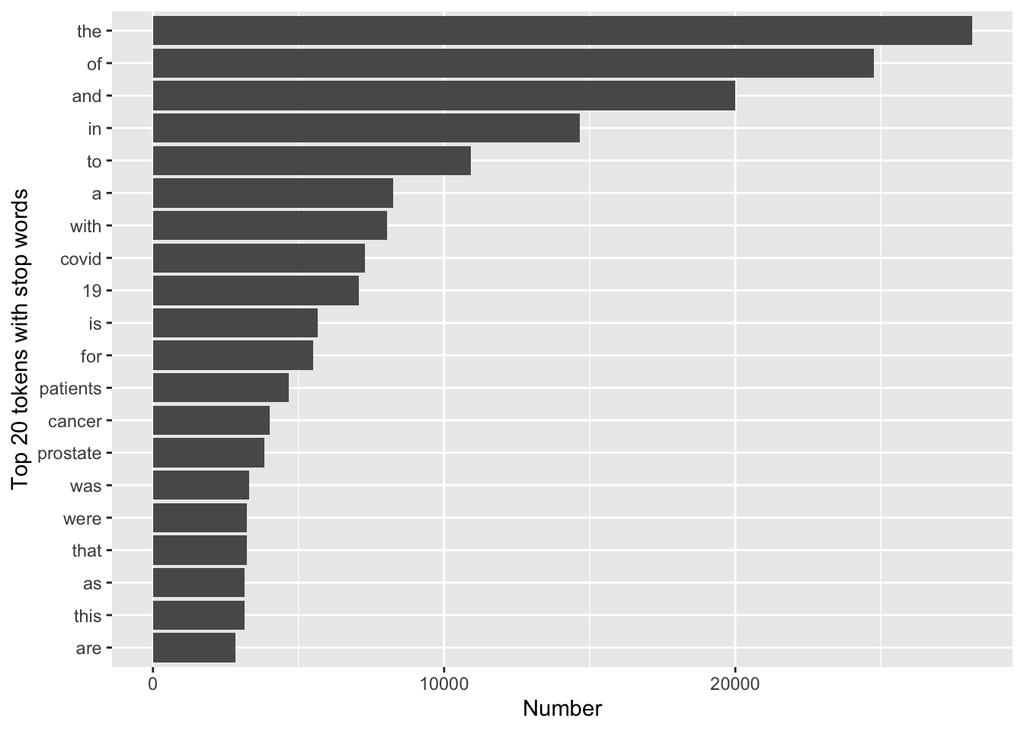

```r
pub %>%
  unnest_tokens(token, abstract) %>%
  count(token, sort = TRUE) %>%
  top_n(20, n) %>%
  ggplot(aes(n, fct_reorder(token, n))) +
  labs(x = "Number", y = "Top 20 tokens with stop words") +
  geom_col()
```

We could find that most the word with high frequency are the stop words. 15 of the top 20 common tokens, especially the top 5, are all stop words. The other 5 tokens with frequency increased by the order are “covid”, “19”, “patients”, “cancer”, and “prostate”. Considering “covid” and “19” are usually used together, this results make sense.

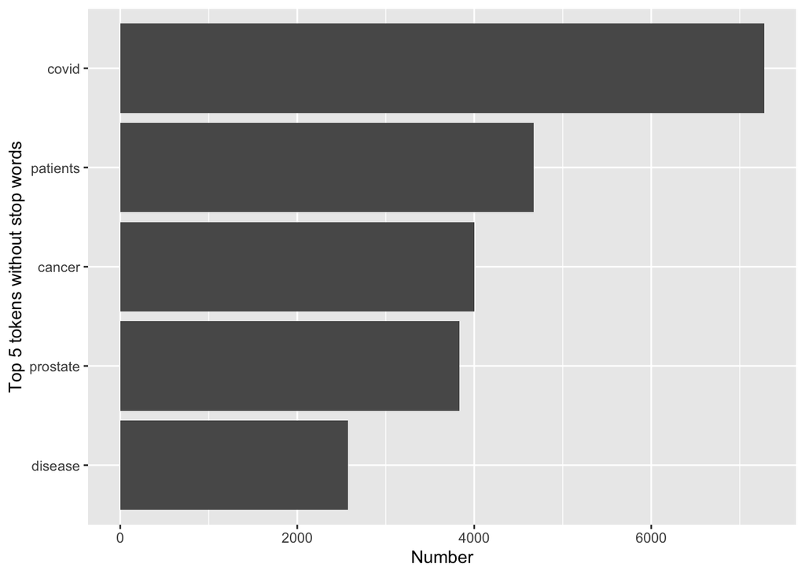

```r
pub %>%
  unnest_tokens(token, abstract) %>%
  anti_join(stop_words, by = c("token" = "word")) %>%
  count(token, sort = TRUE) %>%
  #use regular
  filter(!grepl(pattern = "^[0-9]+$", x = token)) %>%
  top_n(5, n) %>%
  ggplot(aes(n, fct_reorder(token, n))) +
  labs(x = "Number", y = "Top 5 tokens without stop words") +
  geom_col()
```

Considering “covid” and “19” are usually used together, we could also remove the number when we remove the stop words to observe the common words better. After removing process, the result the top 5 tokens with high frequency are all non stop-word, which are the same one mentioned above,“covid”, “patients”, “cancer”, “prostate” and a new one “disease”.

## 2) Tokenize the abstracts into bigrams. Find the 10 most common bigram and visualize them with ggplot2.

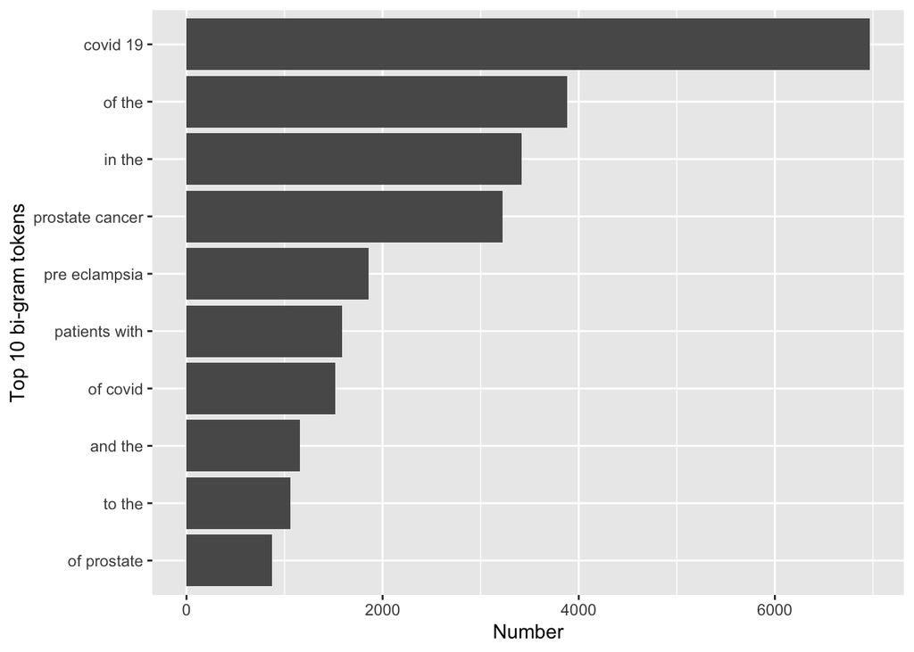

```r
pub %>%
  unnest_ngrams(bigram, abstract, n=2) %>%
  count(bigram, sort = TRUE) %>%
  top_n(10, n) %>%
  ggplot(aes(n, fct_reorder(bigram, n))) +
  labs(x = "Number", y = "Top 10 bi-gram tokens")  +
  geom_col()
```

The 10 most common bi-gram are shown above, “covid 19” are much more than the others. And nearly all the most 10 common bi-gram are the combination of the 20 most common tokens we gained before without removing the stop words and the number.

## 3) Calculate the TF-IDF value for each word-search term combination. (here you want the search term to be the “document”) What are the 5 tokens from each search term with the highest TF-IDF value? How are the results different from the answers you got in question 1?

```r
#tokens with stop words and number
pub %>%
  unnest_tokens(token, abstract) %>%
  count(token, term) %>%
  bind_tf_idf(token, term, n) %>%
  arrange(desc(tf_idf)) %>%
  top_n(5, tf_idf)
```

```
## # A tibble: 5 × 6
##   token        term                n      tf   idf tf_idf
##   <chr>        <chr>           <int>   <dbl> <dbl>  <dbl>
## 1 covid        covid            7275 0.0371   1.61 0.0597
## 2 prostate     prostate cancer  3832 0.0312   1.61 0.0502
## 3 eclampsia    preeclampsia     2005 0.0143   1.61 0.0230
## 4 preeclampsia preeclampsia     1863 0.0133   1.61 0.0214
## 5 meningitis   meningitis        429 0.00919  1.61 0.0148
```

```r
#token without stop words and number
pub %>%
  unnest_tokens(token, abstract) %>%
  anti_join(stop_words, by = c("token" = "word")) %>%
  filter(!grepl(pattern = "^[0-9]+$", x = token)) %>%
  count(token, term) %>%
  bind_tf_idf(token, term, n) %>%
  arrange(desc(tf_idf)) %>%
  top_n(5, tf_idf)
```

```
## # A tibble: 5 × 6
##   token        term                n     tf   idf tf_idf
##   <chr>        <chr>           <int>  <dbl> <dbl>  <dbl>
## 1 covid        covid            7275 0.0722  1.61 0.116
## 2 prostate     prostate cancer  3832 0.0577  1.61 0.0929
## 3 eclampsia    preeclampsia     2005 0.0267  1.61 0.0429
## 4 preeclampsia preeclampsia     1863 0.0248  1.61 0.0399
## 5 meningitis   meningitis        429 0.0172  1.61 0.0278
```

```r
#bi-grams with stop words and number
pub %>%
  unnest_ngrams(bigram, abstract, n=2) %>%
  count(bigram, term) %>%
  bind_tf_idf(bigram, term, n) %>%
  arrange(desc(tf_idf)) %>%
  top_n(5, tf_idf)
```

```
## # A tibble: 5 × 6
##   bigram          term                n      tf   idf tf_idf
##   <chr>           <chr>           <int>   <dbl> <dbl>  <dbl>
## 1 covid 19        covid            6969 0.0357  1.61  0.0575
## 2 prostate cancer prostate cancer  3222 0.0264  1.61  0.0425
## 3 pre eclampsia   preeclampsia     1854 0.0133  1.61  0.0214
## 4 cystic fibrosis cystic fibrosis   859 0.0176  0.916 0.0161
## 5 of covid        covid            1519 0.00779 1.61  0.0125
```

Not matter removing the stop words and the number ore not, the 5 tokens with highest tf_idf value of both are the same, which are “covid”, “prostate”, “eclampsia”, “preeclampsia”, and “meningitis”. For the bi-grams, the 5 tokens with highest tf_idf value are “covid 19”,“prostate cancer”,“pre eclampsia”,“cystic fibrosis”, and “of covid”. Comparing with the 5 common tokens in question 1, “covid”, “patients”, “cancer”, “prostate” and “disease”, the 5 tokens with highest tf_idf value here are prtly different, with only “covid” and “prostate” are the same. Besides, the 5 tokens with highest tf_idf value (“eclampsia”, “preeclampsia”, and “meningitis”) provide more specific and useful information on learning about the research results than the 5 common tokens with highest frequency (“patients”, “cancer”, and “disease”.